# Compositional analysis of microbiome data

Xin (David) Zhao

Last edited 22 December 2022

```r
# This project was built with R 4.2.1

library(ALDEx2)
library(vegan)
library(zCompositions) # for zero treatment in microbiome data
library(compositions)
library(DiagrammeR) # for flow diagram
library(dendextend) # set parameters for plotting dendrograms
library(scales)
library(RColorBrewer)
library(tidyverse)
```

## Introduction

**Compositional data** exists as the proportions, or fractions, of a whole or portions of a total, conveying exclusively relative information, and have the properties: the elements of composition are non-negative and sum to unity.(Xia, Sun, and Chen 2018) Mathematically, compositional data is represented by points on a simplex (i.e., **Aitchison simplex**). Measurements involving probabilities, proportions, percentages, and ppm (10<sup>6</sup>, parts per million), ppb (10<sup>9</sup>, parts per billion)([Wikipedia](https://en.wikipedia.org/wiki/Compositional_data)).

Composition data violate the assumptions of all standard statistical tests because (Xia, Sun, and Chen 2018):

- spurious correlations preclude correlation analysis
- graphical distortions make the visualizing tools impossible (e.g., scatter plot; QQ plot et al.)
- lack of multivariate normality of compositions prevents multivariate parametric modeling of compositional data
- dependence of the mixture makes ANOVA and linear regression meaningless

One critical progress in compositional data analysis since the 1980s to use the **log-ratio transformations**.The book, “Statistical Analysis of Microbiome Data with R” (Xia, Sun, and Chen 2018) provides a list for a family of **log-ratio transformations** popular in microbiome studies as follows,

- Additive Log-ratio (alr) transformation
- Centered Log-ratio (clr) transformation
- Isometric Log-ratio (ilr) transformation

The difference among these three log-ratio transformations is to choose the **divisor**. In other words, it to choose which value to be used to normalize all the values in a sample. Each transformation has its own weakness or advantages (Xia, Sun, and Chen 2018).

Note that log and log-ratio transformations require non-zero elements in the data matrix. As a result, compositional data analysis must be preceded by **a treatment of the zeros**. Three sources of zeros in microbiome data includes:

- Rounded zeros
- Sampling zeros
- Structural zeros

## R workflow

[interactive chart not shown]

## Scripts to implement above procedures

### Step 1. Download raw microbiome data and metadata

The microbiome OTU table and metadata was retrieved from [ML Repo](https://knights-lab.github.io/MLRepo/docs/turnbaugh_lean_obese_all.html)

```r
# raw OTU table
raw_otu <- read.csv(file = "https://knights-lab.github.io/MLRepo/datasets/turnbaugh/refseq/otutable.txt",
                    header=T,
                    sep = "")
```

Read in the metadata from URL.

```r
# metadata

meta <- read.csv(file = "https://knights-lab.github.io/MLRepo/datasets/turnbaugh/task-obese-lean-all.txt",
         header = TRUE,
         sep = "")
```

The metadata contains 142 samples. `Var` indicates the independent, binary variable of interest, `Lean` and `Obese`.

### Step 2. Preprocess input data

Convert the raw OTU table, with samples being rows while OTU being columns.

```r
t_raw_otu <- raw_otu %>%
  gather(key = "sample",
         value = "reads",
         3:ncol(.)) %>%
  dplyr::select(-ID) %>%
  spread(key = names(.)[1],
         value = "reads") %>%
  column_to_rownames("sample")  # convert column to row id
```

Inspect whether any NA (missing values) exits; replace NA with 0 values if any. Follow the instructions introduced [here](https://www.r-bloggers.com/2019/09/handling-missing-values-in-r-using-tidyr/).

```r
sum(is.na(t_raw_otu)) # check number of missing values

na_t_raw_otu <- t_raw_otu %>%
  mutate_all(replace_na, 0) # replace NA with 0 value

sum(is.na(na_t_raw_otu)) # check number of missing values afterwards
```

Evaluate visually 0/missing values patterns in the OTU table with `zPatterns()` from the `zCompositions` package.

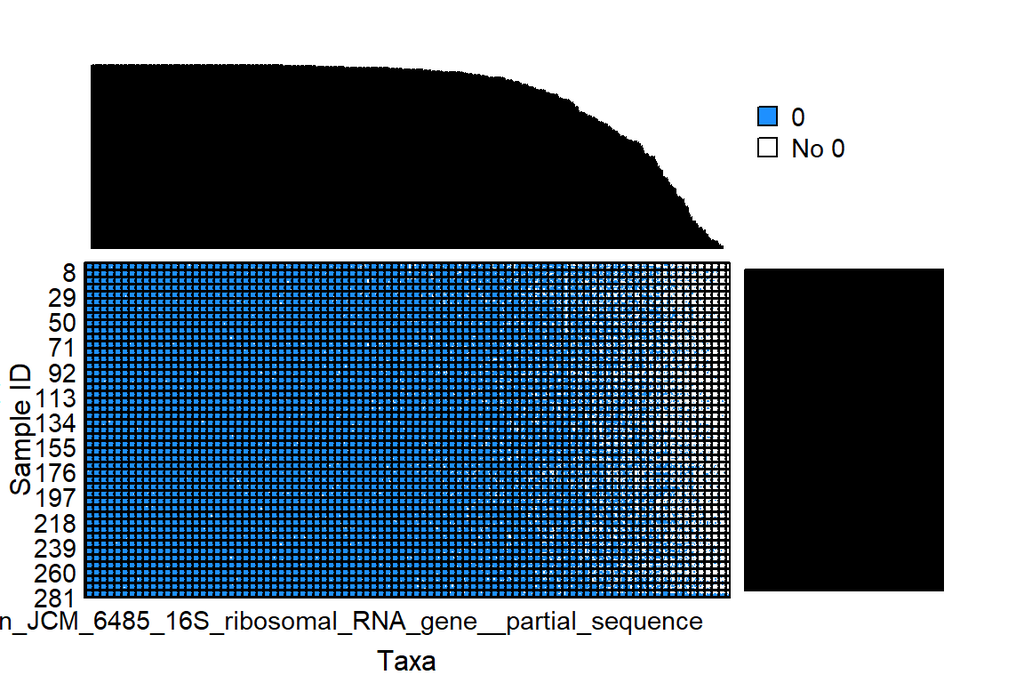

```r
pattern.ID <- zPatterns(na_t_raw_otu,
          label = 0, # identify zero percentages
          axis.labels = c("Taxa", "Sample ID"),
          plot=TRUE,
          show.means = FALSE,
          bar.ordered = c(TRUE, TRUE),
          bar.labels = FALSE,
          suppress.print = TRUE)
```

Apply `cmultRepl()` from the `zCompositions` package to replace 0 values with the count zero multiplicative method and output counts.

Error information, however, appear and the function stops. Therefore, remove samples that are zeros for every OTU. And then implement the above function again.

```r
rm_na_t_raw_otu <- na_t_raw_otu[pattern.ID != 281, ]


rp_rm_na_t_raw_otu <- cmultRepl(rm_na_t_raw_otu,
          method = "CZM", # count zero multiplicative method
          output = "p-counts",  # pseudo-counts
          z.warning=0.8)
## Warning in cmultRepl(rm_na_t_raw_otu, method = "CZM", output = "p-counts", : Column(s) containing more than 80% zeros/unobserved values were found (check it out using zPatterns).
##                     (You can use the z.warning argument to modify the warning threshold).
## Warning in cmultRepl(rm_na_t_raw_otu, method = "CZM", output = "p-counts", : Row(s) containing more than 80% zeros/unobserved values were found (check it out using zPatterns).
##                   (You can use the z.warning argument to modify the warning threshold).
## No. adjusted imputations:  59997
```

### Step 3. Convert data to proportions

Transpose the resulting data frame to OTU X sample format.

```r
pcount_otu <- rp_rm_na_t_raw_otu %>%
  rownames_to_column("sample") %>%
  gather(key = "otu", value = "reads", -sample) %>%
  spread(key = "sample", value = "reads") %>%
  column_to_rownames("otu")

head(pcount_otu)
```

|  | TS1.2.299121 | TS1.299139 | TS10.2.299108 | TS10.299123 | TS100.2.298944 | TS100.298999 | TS101.2.299207 | TS103.2.299213 | TS103.299049 | TS104.2.299106 | TS104.299154 | TS105.2.299038 | TS105.299210 | TS106.2.299179 | TS106.299035 | TS107.2.298960 | TS107.299042 | TS109.2.299100 | TS109.299099 | TS11.2.299208 | TS11.298996 | TS110.2.299101 | TS110.299019 | TS111.2.298964 | TS111.299174 | TS115.2.299043 | TS115.298998 | TS116.2.299078 | TS116.299165 | … |
| --- | --- | --- | --- | --- | --- | --- | --- | --- | --- | --- | --- | --- | --- | --- | --- | --- | --- | --- | --- | --- | --- | --- | --- | --- | --- | --- | --- | --- | --- | --- |
| NR_024643.1_Enterobacter_aerogenes_strain_JCM1235_16S_ribosomal_RNA_gene__partial_sequence | 0.3385636 | 0.3387042 | 0.3401973 | 0.34078786 | 0.34828502 | 0.34429994 | 0.34293985 | 0.330964 | 0.3398952 | 2.090653e-04 | 0.3388254 | 0.3460008 | 0.3370520 | 0.3279454 | 0.34722013 | 0.34198457 | 0.3422457 | 0.34661884 | 0.3404672 | 0.34126966 | 0.34274569 | 0.17065059 | 0.3379164 | 0.34337184 | 0.3392643 | 0.3394283 | 0.3400157 | 0.3391967 | 0.3305081 | … |
| NR_024661.1_Eubacterium_ruminantium_strain_GA195_16S_ribosomal_RNA_gene__partial_sequence | 0.1301128 | 0.1191705 | 0.1054515 | 0.09768784 | 0.05281261 | 0.07624988 | 0.08535942 | 0.330964 | 0.1171373 | 4.731037e-05 | 0.1266339 | 1.0000000 | 0.1442089 | 1.0000000 | 0.06226880 | 0.09318441 | 0.0883613 | 0.06193769 | 0.1031227 | 0.09501208 | 0.08698905 | 0.03861734 | 0.1434904 | 0.08091047 | 0.1288523 | 0.1180696 | 1.0000000 | 0.1157604 | 0.3305081 | … |
| NR_024684.1_Eubacterium_nitritogenes_strain_JCM_6485_16S_ribosomal_RNA_gene__partial_sequence | 0.3385636 | 0.3387042 | 0.3401973 | 0.34078786 | 0.34828502 | 0.34429994 | 0.34293985 | 0.330964 | 0.3398952 | 1.027198e-03 | 0.3388254 | 0.3460008 | 0.3370520 | 0.3279454 | 0.34722013 | 0.34198457 | 0.3422457 | 0.34661884 | 0.3404672 | 0.34126966 | 0.34274569 | 0.35181662 | 0.3379164 | 0.34337184 | 0.3392643 | 0.3394283 | 0.3400157 | 0.3391967 | 0.3305081 | … |
| NR_024712.1_Mogibacterium_vescum_strain_ATCC_700697_16S_ribosomal_RNA_gene__partial_sequence | 0.3385636 | 0.3387042 | 0.3401973 | 0.34078786 | 0.14988353 | 0.21639912 | 0.34293985 | 0.330964 | 0.3398952 | 1.342681e-04 | 0.3388254 | 0.1877386 | 0.3370520 | 0.3279454 | 0.17672045 | 0.34198457 | 0.3422457 | 0.17578074 | 0.3404672 | 0.34126966 | 0.34274569 | 0.10959699 | 0.3379164 | 0.34337184 | 0.3392643 | 0.3394283 | 0.3400157 | 0.3391967 | 0.3305081 | … |
| NR_024719.1_{Clostridium}_hylemonae_strain_TN-272_16S_ribosomal_RNA_gene__partial_sequence | 0.2087290 | 0.1911752 | 0.1691670 | 0.15671241 | 0.08472284 | 0.12232130 | 0.13693496 | 0.330964 | 0.1879136 | 7.589607e-05 | 0.2031482 | 0.1061207 | 0.3370520 | 0.3279454 | 0.09989262 | 0.14948793 | 0.1417506 | 0.09936144 | 0.1654311 | 0.15241991 | 0.13954924 | 0.06195056 | 0.3379164 | 0.12979789 | 0.2067069 | 0.1894092 | 0.1806718 | 0.1857047 | 0.3305081 | … |
| NR_024733.1_Coprobacillus_cateniformis_strain_JCM_10604_16S_ribosomal_RNA_gene__partial_sequence | 0.3385636 | 0.2071671 | 0.1833179 | 1.00000000 | 1.00000000 | 0.13255355 | 2.00000000 | 0.330964 | 0.2036326 | 8.224482e-05 | 0.2201416 | 0.1149978 | 0.3370520 | 4.0000000 | 0.10824869 | 0.16199269 | 0.1536081 | 0.10767309 | 0.1792695 | 0.16516993 | 0.15122262 | 0.06713276 | 0.3379164 | 0.14065557 | 0.3392643 | 0.2052534 | 0.1957851 | 0.2012390 | 0.3305081 | … |

Calculate total pcount throughout samples.

```r
pcount_otu %>%
  rownames_to_column("otu") %>%
  gather(key= "sample", value = "pcount", -otu) %>%
  group_by(sample) %>%
  summarise(total = sum(pcount), .groups = "drop")
```

| sample | total |
| --- | --- |
| TS1.2.299121 | 3107.493334 |
| TS1.299139 | 2846.157603 |
| TS10.2.299108 | 2518.506503 |
| TS10.299123 | 2333.086103 |
| TS100.2.298944 | 1261.327592 |
| TS100.298999 | 1821.081816 |
| TS101.2.299207 | 2038.645537 |
| TS103.2.299213 | 8283.264757 |
| TS103.299049 | 2797.599167 |
| TS104.2.299106 | 1.129917 |

[output cut: 270 more lines]

Calculate proportions based on pseudo counts.

```r
prop_pcount_otu <- pcount_otu %>%
  map_dfr(function(x) x/sum(x))

rownames(prop_pcount_otu) <- rownames(pcount_otu)  # assign row names to the resulting data frame
## Warning: Setting row names on a tibble is deprecated.
```

### Step 4. Filter rare taxa

```r
otu_id_dropped <- prop_pcount_otu %>%
  rownames_to_column("otu") %>%
  gather(key = "sample", value="prop", -otu) %>%
  group_by(otu) %>%
  summarise(max = max(prop)) %>%
  ungroup() %>%
  filter(max < 0.0001) %>% # minimal proportional threshold 0.01%
  pull(otu)

# remove OTU not passing 0.01% threshold
pcount_otu_fl <- pcount_otu %>%
  rownames_to_column("otu") %>%
  filter(!otu %in% otu_id_dropped) %>%
  column_to_rownames("otu")
```

### Step 5. Perform the clr transformation

```r
# extract the descendingly ordered taxa
desc_otu_id <- pcount_otu_fl %>%
  rownames_to_column("otu") %>%
  gather(key = "sample", value = "pcount", -otu) %>%
  group_by(otu) %>%
  summarise(total = sum(pcount)) %>%
  arrange(desc(total)) %>%
  pull(otu)


# re-order the pcount OTU table
pcount_otu_fl_desc <- pcount_otu_fl[desc_otu_id, ]


# clr transformation
pcount_otu_fl_desc_clr <- t(apply(pcount_otu_fl_desc, 2, function(x) {log(x) - mean(log(x))}))

pcount_otu_fl_desc_clr <- data.frame(pcount_otu_fl_desc_clr)  # convert to data frame format
```

### Step 6. Princinpal component analysis of clr-transformed OTU matrix

Conduct principal component analysis on the compositional data set using `prcomp()`

```r
pca_clr <- prcomp(pcount_otu_fl_desc_clr)

summary(pca_clr)
```

### Step 7. PCA plot

```r
# extract PC1-2 for all samples
pc2 <- data.frame(pca_clr$x[,1:2])

# merge metadata
pc2_meta <- pc2 %>%
  rownames_to_column("sample") %>%
  inner_join(meta, by = c("sample" = "X.SampleID")) %>%
  rename(is_obese = Var) %>%
  mutate(is_obese = factor(is_obese, levels = c("Obese", "Lean"))) %>%
  select(-ControlVar)
```

Produce PCA plot with `ggplot2` package.

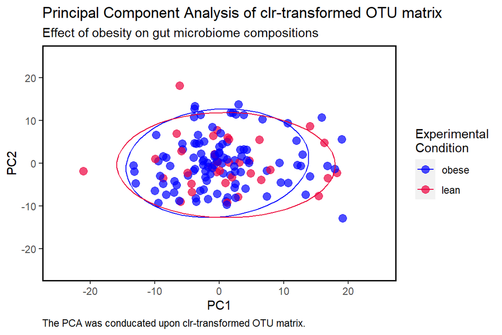

```r
# plotting with ggplot2
ggplot(pc2_meta, aes(x=PC1,
                     y=PC2,
                     color=is_obese))+
  geom_point(alpha = 0.7,
             size=3) +
  stat_ellipse()+ # add ellipses
  scale_color_manual(values = c("#0000FF", "#ED003E"),
                     name = "Experimental\nCondition",  # change text of legend title
                     labels = c("obese", "lean")) + # change text of legend labels
  scale_y_continuous(limits = c(-25, 25)) +  # change the y-axis ranges
  scale_x_continuous(limits = c(-25, 25)) +  # change the x-axis ranges
  labs(title = "Principal Component Analysis of clr-transformed OTU matrix",
       subtitle = "Effect of obesity on gut microbiome compositions",
       caption = "The PCA was conducated upon clr-transformed OTU matrix.") +
  theme(panel.background = element_blank(),
        panel.border = element_rect(colour = "black", fill = NA, size = 1),
        plot.caption = element_text(hjust = 0))
```

### Step 8. Scree plot of princinpal component analysis

Use scree plot to display the proportion of the total variation in the data set that is explained by each of the components in a principal component analysis.

Create the scree plot using `ggplot2` following the online [instruction](https://www.statology.org/scree-plot-r/).

```r
# calculate total variance explained by each principal component
var_explained <- pca_clr$sdev^2 / sum(pca_clr$sdev^2)

var_explained[1:4]  # take a look at variations of four PCs
```

```
## [1] 0.09016477 0.06422212 0.05680660 0.03513550
```

The first principal component explains 9.0% of the total variation in the data set; the second principal component explains 6.4% of the total variation in the data set.

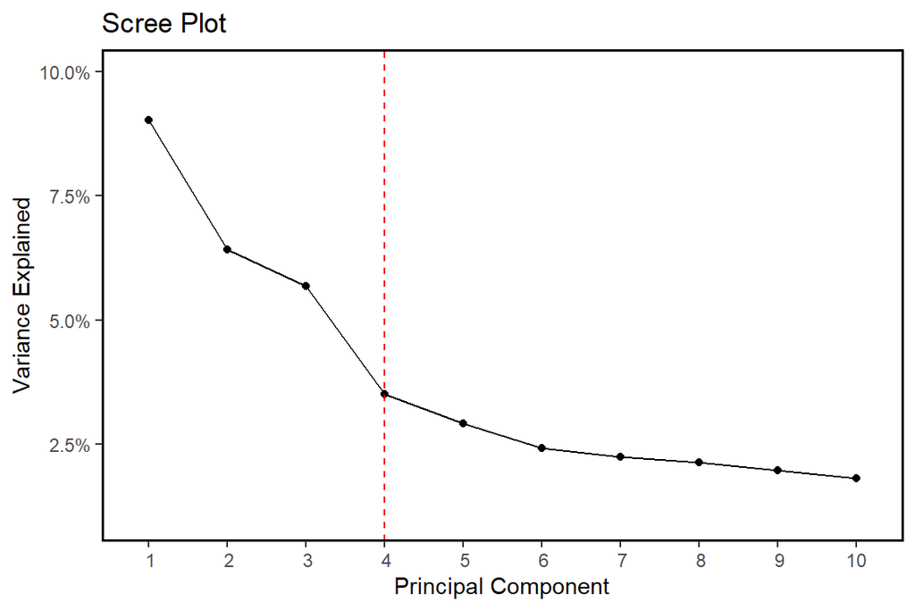

```r
# store var_explained in the data frame
var_explained_df <- data.frame(PC = c(1:10),
                               var_exp = var_explained[1:10])


ggplot(var_explained_df,
       aes(x= PC,
           y= var_exp)) +
  geom_point() +
  geom_line() +
  xlab("Principal Component") +
  ylab("Variance Explained") +
  scale_x_discrete(limits = c(1:10)) +
  scale_y_continuous(limits = c(0.01, 0.1),
                     labels = scales::percent)+
  geom_vline(xintercept = 4, color = "red", linetype = "dashed")+
  ggtitle("Scree Plot") +
  theme(panel.background = element_blank(),
        panel.border = element_rect(colour = "black", fill = NA, size = 1))
## Warning: Continuous limits supplied to discrete scale.
## Did you mean `limits = factor(...)` or `scale_*_continuous()`?
```

According to the scree test, the “elbow” of the graph where the eigenvalues seem to level off is found and factors or components to the left of this point should be retained as significant.

### Step 9. Hierarchical cluster analysis

Hierarchical cluster analysis (e.g., principles, methods and implementations) is well documented in [GustaMe](https://sites.google.com/site/mb3gustame/dissimilarity-based-methods/cluster-analysis/hierarchical-cluster-analysis), and widely used in exploratory data analysis of microbiome data.

Conduct a cluster analysis and plot cluster dendrogram on dissimilarity based on the `clr-transformed` OTU matrix. Use `Euclidian` distance because the Aitchison transformed data are linearly related, but all distances should be calculated from the ratios.

```r
# calculate distance matrix
dist <- dist(pcount_otu_fl_desc_clr,  # input clr-transformed OTU data
             method = "euclidian")  # Euclidian distance

# cluster the data
hc_ward.d2 <- hclust(dist, # dissimilarity structure as produced by dist
                     method = "ward.D2") # the agglomeration algorithm used
```

Draw dendrogram with the base R function and ggplot2-based function as alternative, following the instructions on [STHDA](http://www.sthda.com/english/wiki/beautiful-dendrogram-visualizations-in-r-5-must-known-methods-unsupervised-machine-learning) and [stackoverflow](https://stackoverflow.com/questions/49088627/how-to-label-colored-bars-in-a-dendrogram).

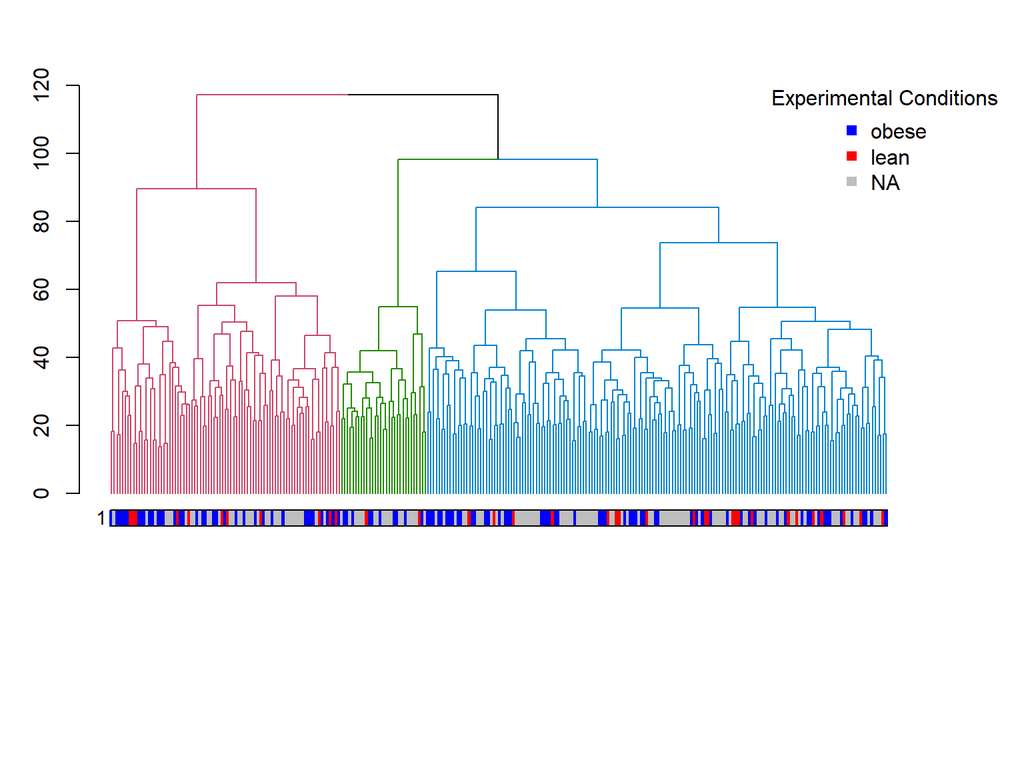

```r
# create dendrogram object
dend_ward.d2 <- hc_ward.d2 %>%
  as.dendrogram

# # get the labels of the tree/ dendrogram
# labels(dend_ward.d2)

# extract the grouping variable for labels

label_id <- data.frame(X.SampleID = labels(dend_ward.d2))  # extract tree labels

label_meta <- plyr::join(label_id, meta)  # full join two data sets keeping original order of tree labels

# assign node color by experimental conditions
node_col_df <- label_meta %>%
  mutate(node_col = case_when(
    Var == "Obese" ~ "blue",
    Var == "Lean" ~ "red",
    is.na(Var) ~ "grey"
  )) %>%
  mutate(bar_code = case_when(
    Var == "Obese" ~ 1,
    Var == "Lean" ~ 2,
    is.na(Var) ~ 3
  ))


# Set the plot margin: bottom, left, top & right
par(mar = c(10, 3, 3, 4) + 0.1,
    xpd = NA) # allow content to go into outer margin

# dendrogram plot without labels
dend_ward.d2 %>%
  set("labels", '') %>%
  set("branches_k_color", k=3) %>%
  plot
## Warning in `labels<-.dendrogram`(dend, value = value, ...): The lengths of the
## new labels is shorter than the number of leaves in the dendrogram - labels are
## recycled.

# set up the color bar
node_col2 <- node_col_df %>% pull(node_col)
colored_bars(colors = node_col2, dend = dend_ward.d2, y_shift = -5)

# add legend manually
legend("topright", legend = c('obese', 'lean', 'NA'),
       pch = 15,
       pt.cex = 1,
       cex = 1,
       bty = 'n',
       inset = c(-0.1, 0), # place outside
       title = "Experimental Conditions",
       col = c('blue', 'red', 'grey'))
```

### Step 10. Bar plot of microbiota composition

Use Aitchison composition, `acomp()` function to analyze compositions in the philosophical framework of the Aitchison Simplex. The input to `acomp()` is absolute count (read) data in the sample X taxa format. The output of `acomp()` represents one closed composition or a matrix of class `acomp` represents multiple closed compositions each in one row.

The website, [rdocumentation](https://www.rdocumentation.org/packages/compositions/versions/2.0-4/topics/acomp) provides a code example of running `acomp()` function.

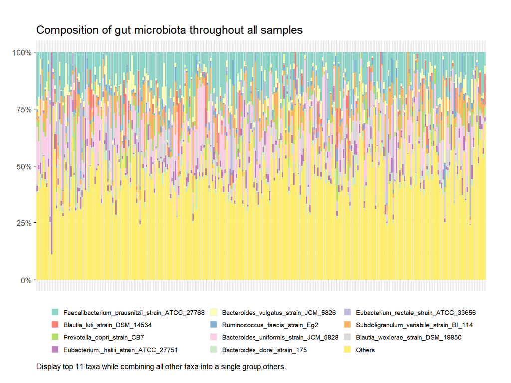

```r
# reorder according to clustering structure
pcount_otu_fl_reorder <- pcount_otu_fl[ ,hc_ward.d2$order]  # the input data is OTU count data after 0 replacement


# create acomp vector
re_order_acomp <- acomp(t(pcount_otu_fl_reorder))  # row sum of acomp output is 1



# display top 11 taxa based on mean relative abundance; while combining all other taxa as a single group 'others'
re_order_acomp_df <- data.frame(re_order_acomp)

# top11 taxa
top11_taxa <- re_order_acomp_df %>%
  rownames_to_column("sample") %>%
  gather(key = "otu", value = "rel_abund", -sample) %>%
  group_by(otu) %>%
  summarise(total = sum(rel_abund)) %>%
  arrange(desc(total)) %>%
  head(11) %>%
  pull(otu)

rel.abund_regroup <- re_order_acomp_df %>%
  rownames_to_column("sample") %>%
  gather(key = "otu", value = "rel_abund", -sample) %>%
  mutate(otu2 = case_when(
    otu %in% top11_taxa ~ otu,
    !otu %in% top11_taxa ~ "others"
  )) %>%
  group_by(sample, otu2) %>%
  summarise(rel_abund2 = sum(rel_abund))


# create the bar plot using ggplot2

top11_taxa_shorten <- c("Faecalibacterium_prausnitzii_strain_ATCC_27768",
                        "Bacteroides_vulgatus_strain_JCM_5826",
                        "Eubacterium_rectale_strain_ATCC_33656",
                        "Blautia_luti_strain_DSM_14534",
                        "Ruminococcus_faecis_strain_Eg2",
                        "Subdoligranulum_variabile_strain_BI_114",
                        "Prevotella_copri_strain_CB7",
                        "Bacteroides_uniformis_strain_JCM_5828",
                        "Blautia_wexlerae_strain_DSM_19850",
                        "Eubacterium._hallii_strain_ATCC_27751",
                        "Bacteroides_dorei_strain_175",
                        "Others")

ggplot(rel.abund_regroup,
       aes(x= sample,
           y= rel_abund2,
           fill=otu2))+
  geom_bar(position = "stack", stat = "identity", color = NA) +
  # remove x-axis labels
  theme(axis.text.x = element_blank(),
        axis.ticks.x = element_blank()) +
  # remove axis titles
  theme(axis.title = element_blank()) +
  # y-axis percentage
  scale_y_continuous(labels = percent) +
  # legend with shorten taxa names, below figure
  scale_fill_brewer(palette = "Set3",
                    labels = top11_taxa_shorten) +
  # color palette, Set3
  # remove samples with missing data
  theme(plot.margin = margin(1,1,0.5,0.5, "cm")) +
  # deal with legends
  theme(legend.position = "bottom") +
  guides(fill = guide_legend(nrow = 4, byrow = T)) +
  theme(legend.key.size = unit(0.3, "cm"),
        legend.text = element_text(size = 7),
        legend.title = element_blank()) +
  # title, caption
  labs(title = "Composition of gut microbiota throughout all samples",
       caption = "Display top 11 taxa while combining all other taxa into a single group,others.") +
  theme(plot.caption = element_text(hjust = 0))
```

### Step 11. Perform the Welch’s t and Wilcoxon Rank Sum Test using `aldex.ttest()`

ALDEx2 needs the input data with taxa by samples formats.

```r
# metadata
is.obese <- meta %>%
  rename(sample = X.SampleID,
         is_obese = Var) %>%
  select(-ControlVar)

# otu count data
na_t_raw_otu2 <- na_t_raw_otu %>%
  rownames_to_column("sample")

# merge metadata and count data
groups <- na_t_raw_otu2 %>%
  inner_join(is.obese, by= "sample") %>%
  pull(is_obese)

length(groups)  # 142 samples

groups <- factor(groups)


# subset count data
na_t_raw_otu3 <- na_t_raw_otu2 %>%
  inner_join(is.obese, by= "sample") %>%
  select(-is_obese) %>%
  gather(key = "otu", value= "reads", -sample) %>%
  spread(key = "sample", value = "reads") %>%
  column_to_rownames("otu")

# input count data to ALDEX2
aldex_raw_count <- na_t_raw_otu3
```

Generate instances of the centered log-ratio transformed values using the function `aldex.clr()`

The function `aldex.clr()` has three input:

- count table
- number of Monte-Carlo instances
- level of verbosity (TRUE or FALSE)

The package authors recommend 128 or more `mc.samples` for the t-test, 1000 for a rigorous effect size calculation, and at least 16 for ANOVA.

```r
vdr <- aldex.clr(aldex_raw_count,
                 groups,
                 mc.samples = 128,
                 verbose = TRUE)
```

Perform the Welch’s and Wilcoxon rank sum test using `aldex.ttest()`

The function `aldex.ttest()` returns the values:

- `we.ep` (expected p-value of Welch’s t test)
- `we.eBH` (expected Benjamini-Hochberg corrected p-value of Welch’s t test)
- `wi.ep` (expected p-value of Wilcoxon rank sum test)
- `wi.eBH` (expected Benjamini-Hochberg corrected p-value of Wilcoxon rank sum test)

```r
vdr_t <- aldex.ttest(vdr, paired.test=FALSE, hist.plot=FALSE, verbose=FALSE)

head(vdr_t)
```

|  | we.ep | we.eBH | wi.ep | wi.eBH |
| --- | --- | --- | --- | --- |
| NR_024643.1_Enterobacter_aerogenes_strain_JCM1235_16S_ribosomal_RNA_gene__partial_sequence | 0.4994517 | 0.9462585 | 0.5079608 | 0.9485912 |
| NR_024661.1_Eubacterium_ruminantium_strain_GA195_16S_ribosomal_RNA_gene__partial_sequence | 0.5284665 | 0.9594873 | 0.5063860 | 0.9622426 |
| NR_024684.1_Eubacterium_nitritogenes_strain_JCM_6485_16S_ribosomal_RNA_gene__partial_sequence | 0.4820306 | 0.9507166 | 0.5015875 | 0.9587592 |
| NR_024712.1_Mogibacterium_vescum_strain_ATCC_700697_16S_ribosomal_RNA_gene__partial_sequence | 0.4783075 | 0.9491080 | 0.5262787 | 0.9595154 |
| NR_024719.1_{Clostridium}_hylemonae_strain_TN-272_16S_ribosomal_RNA_gene__partial_sequence | 0.5117365 | 0.9470355 | 0.4908678 | 0.9581154 |
| NR_024733.1_Coprobacillus_cateniformis_strain_JCM_10604_16S_ribosomal_RNA_gene__partial_sequence | 0.5364265 | 0.9620383 | 0.5457310 | 0.9628450 |

Estimate effect size using the function `aldex.effect()`

The `aldex.effect()` function estimates effect size and the within and between condition values in the case of two conditions.

It has 3 arguments:

- the aldex object from aldex.clr()
- a flag indicating whether or not to include values for all samples are used as the denominator
- the level of verbosity

```r
vdr_effect <- aldex.effect(vdr, include.sample.summary = FALSE, verbose = FALSE)

vdr_effect
```

|  | rab.all | rab.win.Lean | rab.win.Obese | diff.btw | diff.win | effect | overlap |
| --- | --- | --- | --- | --- | --- | --- | --- |
| NR_024643.1_Enterobacter_aerogenes_strain_JCM1235_16S_ribosomal_RNA_gene__partial_sequence | -0.327533666 | -0.365305974 | -0.311679591 | -0.0400848657 | 4.251581 | -0.0057514533 | 0.4964286 |
| NR_024661.1_Eubacterium_ruminantium_strain_GA195_16S_ribosomal_RNA_gene__partial_sequence | 0.507684065 | 0.387831520 | 0.547891670 | 0.2080621703 | 4.099262 | 0.0408466688 | 0.4776786 |
| NR_024684.1_Eubacterium_nitritogenes_strain_JCM_6485_16S_ribosomal_RNA_gene__partial_sequence | -0.322356767 | -0.432029950 | -0.290610518 | 0.1290976492 | 4.138995 | 0.0263327653 | 0.4834821 |
| NR_024712.1_Mogibacterium_vescum_strain_ATCC_700697_16S_ribosomal_RNA_gene__partial_sequence | -0.224882593 | -0.219398209 | -0.225684740 | 0.0019619597 | 4.239691 | 0.0005079579 | 0.4997769 |
| NR_024719.1_{Clostridium}_hylemonae_strain_TN-272_16S_ribosomal_RNA_gene__partial_sequence | -0.302625101 | -0.206110941 | -0.333676945 | -0.1620996218 | 4.187757 | -0.0356566858 | 0.4852679 |
| NR_024733.1_Coprobacillus_cateniformis_strain_JCM_10604_16S_ribosomal_RNA_gene__partial_sequence | 0.264582755 | 0.184930886 | 0.286500055 | 0.0068166090 | 4.650522 | 0.0011876708 | 0.4993307 |
| NR_024750.1_Coprococcus_catus_strain_VPI-C6-61_16S_ribosomal_RNA_gene__partial_sequence | 1.403254700 | 1.930588902 | 1.264996418 | -0.8016640272 | 5.180108 | -0.1362145457 | 0.4346274 |
| NR_024815.1_Prevotella_shahii_strain_EHS11_16S_ribosomal_RNA_gene__partial_sequence | -0.323121616 | -0.318000958 | -0.325133199 | 0.0033968534 | 4.166511 | 0.0006647481 | 0.4995536 |
| NR_024842.1_Streptococcus_parasanguinis_strain_ATCC_15912_16S_ribosomal_RNA_gene__partial_sequence | 1.245446020 | 1.460968198 | 1.168684881 | -0.2346457270 | 4.074471 | -0.0507326267 | 0.4691964 |
| NR_024861.1_Citrobacter_farmeri_strain_CDC_2991-81_16S_ribosomal_RNA_gene__partial_sequence | -0.382690242 | -0.449530167 | -0.355821565 | 0.0556832289 | 4.277822 | 0.0114614976 | 0.4935297 |

[output cut: 476 more lines]

The function, `aldex.effect()` returns all values including,

- `rab.all` median clr value for all samples in the feature
- `rab.win.Lean` median clr value for the `Lean` group of samples
- `rba.win.Obese` median clr value for the `Obese` groups of samples
- `dif.btw` median difference in clr values between `Lean` and `Obese` groups
- `dif.win` median of the largest difference in clr values within `Lean` and `Obese` groups
- `effect` median effect size: `diff.btw/max(diff.win)` for all instances
- `overlap` proportion of effect size that overlaps 0: it is overlap between the Bayesian distribution of `Lean` and `Obese`

```r
# Merge all outputs into one single object and make a data frame for result viewing and downstream analysis

vdr_all <- data.frame(vdr_t, vdr_effect)

head(vdr_all)
```

|  | we.ep | we.eBH | wi.ep | wi.eBH | rab.all | rab.win.Lean | rab.win.Obese | diff.btw | diff.win | effect | overlap |
| --- | --- | --- | --- | --- | --- | --- | --- | --- | --- | --- | --- |
| NR_024643.1_Enterobacter_aerogenes_strain_JCM1235_16S_ribosomal_RNA_gene__partial_sequence | 0.4994517 | 0.9462585 | 0.5079608 | 0.9485912 | -0.3275337 | -0.3653060 | -0.3116796 | -0.040084866 | 4.251581 | -0.0057514533 | 0.4964286 |
| NR_024661.1_Eubacterium_ruminantium_strain_GA195_16S_ribosomal_RNA_gene__partial_sequence | 0.5284665 | 0.9594873 | 0.5063860 | 0.9622426 | 0.5076841 | 0.3878315 | 0.5478917 | 0.208062170 | 4.099262 | 0.0408466688 | 0.4776786 |
| NR_024684.1_Eubacterium_nitritogenes_strain_JCM_6485_16S_ribosomal_RNA_gene__partial_sequence | 0.4820306 | 0.9507166 | 0.5015875 | 0.9587592 | -0.3223568 | -0.4320300 | -0.2906105 | 0.129097649 | 4.138995 | 0.0263327653 | 0.4834821 |
| NR_024712.1_Mogibacterium_vescum_strain_ATCC_700697_16S_ribosomal_RNA_gene__partial_sequence | 0.4783075 | 0.9491080 | 0.5262787 | 0.9595154 | -0.2248826 | -0.2193982 | -0.2256847 | 0.001961960 | 4.239691 | 0.0005079579 | 0.4997769 |
| NR_024719.1_{Clostridium}_hylemonae_strain_TN-272_16S_ribosomal_RNA_gene__partial_sequence | 0.5117365 | 0.9470355 | 0.4908678 | 0.9581154 | -0.3026251 | -0.2061109 | -0.3336769 | -0.162099622 | 4.187757 | -0.0356566858 | 0.4852679 |
| NR_024733.1_Coprobacillus_cateniformis_strain_JCM_10604_16S_ribosomal_RNA_gene__partial_sequence | 0.5364265 | 0.9620383 | 0.5457310 | 0.9628450 | 0.2645828 | 0.1849309 | 0.2865001 | 0.006816609 | 4.650522 | 0.0011876708 | 0.4993307 |

Check any significant taxa between obese and lean conditions detected in both Welch’s t-test and Wilcoxon rank sum tests.

```r
sig_by_both <- vdr_all %>%
  filter(we.ep <= 0.05 & wi.ep <= 0.05)

sig_by_both
```

| we.ep | we.eBH | wi.ep | wi.eBH | rab.all | rab.win.Lean | rab.win.Obese | diff.btw | diff.win | effect | overlap |
| --- | --- | --- | --- | --- | --- | --- | --- | --- | --- | --- |

Any taxa remain significant when p-values are adjusted for multiple testing correction using BH method.

```r
sig_by_both_fdr <- vdr_all %>%
  filter(we.eBH <= 0.05 & wi.eBH <= 0.05)

sig_by_both_fdr
```

| we.ep | we.eBH | wi.ep | wi.eBH | rab.all | rab.win.Lean | rab.win.Obese | diff.btw | diff.win | effect | overlap |
| --- | --- | --- | --- | --- | --- | --- | --- | --- | --- | --- |

### Step 12. Bland-Altman plot (also known as “difference plot”)

The point underlying the method is that any two methods designing to measure the same property or parameter should have agree sufficiently closely, but not merely highly correlated.

`ALDEX2` provides a Bland-Altman (MA) style plot to graphically compare the degree of agreement of measures between median log2 between-condition difference and median log2 relative abundance.

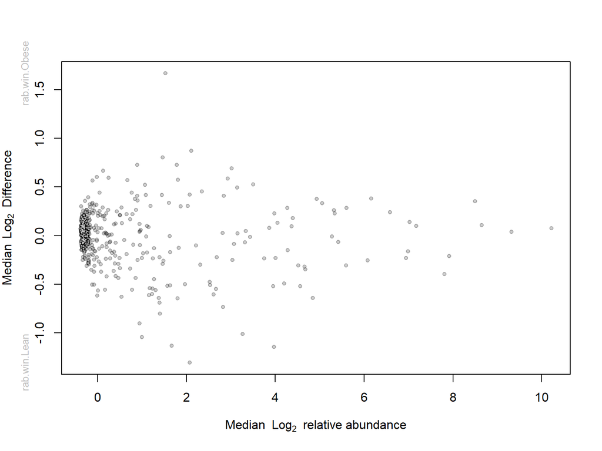

```r
aldex.plot(vdr_all,
           type = "MA", # specifies plot type to be produced
           test = "welch", # indicates using Welch's t test to calculate significance
           cutoff.pval = 0.15,
           all.cex = 0.7, # symbol size
           called.cex = 1.1, # specify the character expansion of points with FDR, q<= 0.1
           rare.col = "grey", # grey for rare taxa
           called.col = "red")  # present those taxa that have a mean BH adjusted Wilcoxon rank sum test p-value of 0.15 or less
```

Effect size and effect size plot In ALDEX2, the effect size is defined as a measure of the mean ratio of the difference between groups (diff.btw) and the maximum difference within groups (diff.win or variance).

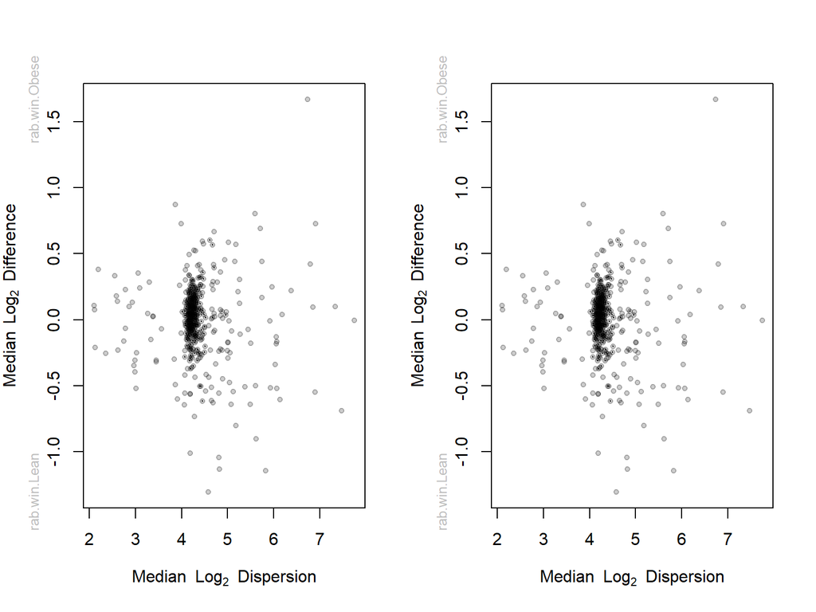

```r
par(mfrow = c(1,2))
aldex.plot(vdr_all,
           type = "MW",
           test = "welch",
           cutoff.pval = 0.15,
           all.cex = 0.7,
           called.cex = 1.1,
           rare.col = "black",
           called.col = "red")
aldex.plot(vdr_all,
           type = "MW",
           test = "wilcox",
           cutoff.pval = 0.15,
           all.cex = 0.7,
           called.cex = 1.1,
           rare.col = "black",
           called.col = "red")
```

In general, p-value is less robust than effect size. Thus, researchers prefer to report effect size more often than the p-value. **If sample size is sufficiently large, an effect size of 0.5 or greater is considered more likely corresponding to biological relevance**.

In `ALDEX2`, an effect size cutoff of 1.5 - 2 and an overlap cutoff of 0.01 is considered as more appropriate to identify differential taxa of interest.

Here, illustrate two additional plots about effect size: 1. plot the effect size versus the p-value 2. a volcano plot to show difference between groups versus p-values

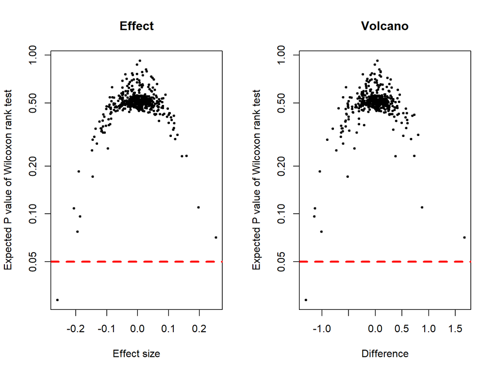

```r
par(mfrow = c(1,2))
plot(vdr_all$effect,
     vdr_all$wi.ep,
     log="y",
     pch=19,
     main = "Effect",
     cex=0.5,
     xlab = "Effect size",
     ylab= "Expected P value of Wilcoxon rank test")
abline(h = 0.05, lty=2, lwd = 3, col="red")
plot(vdr_all$diff.btw, vdr_all$wi.ep,
     log="y",
     pch=19,
     main = "Volcano",
     cex=0.5,
     xlab="Difference",
     ylab="Expected P value of Wilcoxon rank test")
abline(h=0.05, lty=2, lwd=3, col="red")
```

Xia, Yinglin, Jun Sun, and Ding-Geng Chen. 2018. *Statistical Analysis of Microbiome Data with r*. Springer Singapore. https://doi.org/10.1007/978-981-13-1534-3.